# LeMaRns

## Biomass

The biomass of each species at time $t$ is defined as:
$$\begin{equation*}
B_{i,t}=\sum_{j=1}^{n_l}N_{j,i,t}W_{j,i}.
\end{equation*}$$

In `LeMaRns` the biomass of each species can be calculated using the `get_biomass` function. There are several ways in which this function can be used. For example, users can pass `N` and `wgt` to the function directly:

```r
biomass <- get_biomass(N=N, wgt=wgt)
```

or they can provide both `LeMans_param` and a `LeMans_output` objects:

```r
biomass <- get_biomass(inputs=NS_params, outputs=model_run)
```

Options also exist that allow users to specify the `species` and `time_steps` they would like the to calculate the biomass for. `species` can be specified either as a numeric vector:

```r
biomass <- get_biomass(inputs=NS_params, outputs=model_run, time_steps=1:500, species=1:4)
```

or as a character vector:

```r
biomass <- get_biomass(inputs=NS_params, outputs=model_run, time_steps=1:500,
                       species=c("Herring", "Whiting", "Haddock", "Cod"))
```

If more than one `species` is provided, the `get_biomass()` function returns a matrix with dimensions `length(time_steps)` by `length(species)` where the ${i,j}$th element is the biomass (g) of the $j$th `species` in the $i$th `time_steps`. If only one species is provided, the function returns a numeric vector of length `length(time_steps)`.

A similar set of methods can be used to plot the biomass of each species using the `plot_biomass` function. For example, running either:

```r
plot_biomass(N=N, wgt=wgt, time_steps=1:500, species=1:4)
```

or

```r
plot_biomass(inputs=NS_params, outputs=model_run, time_steps=1:500, species=1:21)
```

returns the following plot:

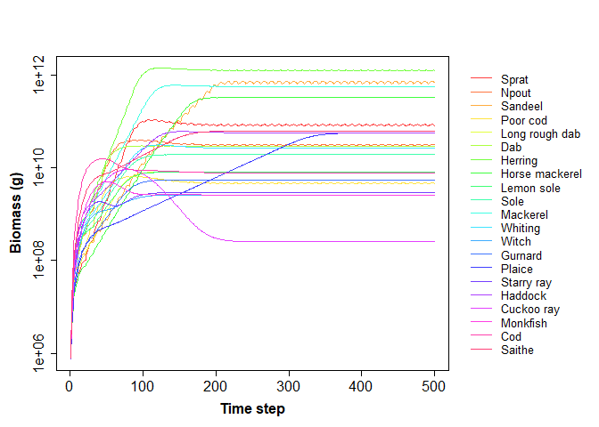

Alternatively, users may pass the outputs of `get_biomass` to the `plot_biomass` function directly as shown below:

```r
biomass <- get_biomass(inputs=NS_params, outputs=model_run)
plot_biomass(biomass=biomass, time_steps=1:500, species=1:4)
```

The `full_plot_only` option allows users to specify whether individual plots should also be produced for each species. For example, the following plots are returned by setting `full_plot_only` to `FALSE`:

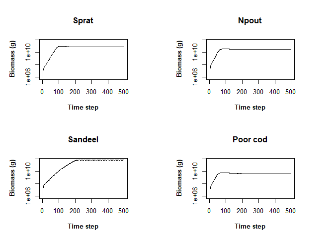

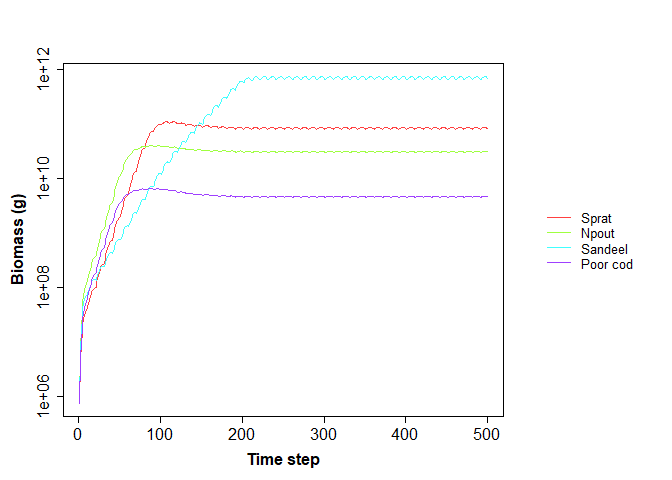

```r
plot_biomass(inputs=NS_params, outputs=model_run, time_steps=1:500, species=1:4,
             full_plot_only=FALSE)
```

Note that if a `LeMans_param` object is passed to the `plot_biomass` function, the plot will be labelled with the correct species names. However, if a `LeMans_param` object is not provided, the species will be labelled as “Species 1”, “Species 2” etc. unless users specify `species_names` directly.

## Spawning Stock Biomass (SSB)

The SSB of each species at time $t$ is defined as:
$$\begin{equation*}
SSB_{i,t}=\sum_{j=1}^{n_l}M_{j,i}N_{j,i,t}W_{j,i}
\end{equation*}$$

where $M_{j,i}$ is the proportion of mature individuals of species $i$ in length class $j$.

In `LeMaRns` the SSB of each species can be calculated using the `get_SSB` function and plotted using the `plot_SSB` function, both of which work in exactly the same way as `get_biomass` and `plot_biomass` as described above. For example, species-specific SSB may be calculated and plotted by running:

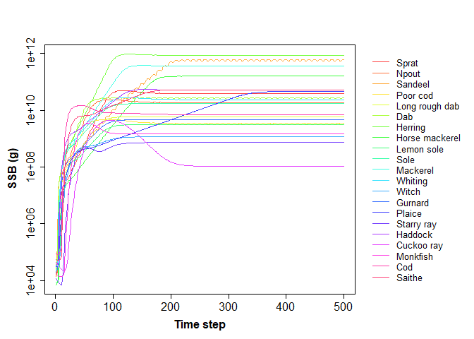

```r
SSB <- get_SSB(inputs=NS_params, outputs=model_run, time_steps=1:500, species=1:21)
plot_SSB(SSB=SSB, time_steps=1:500, species=1:21, species_names=NS_params@species_names)
```

## Indicators

As previously mentioned, `LeMaRns` also includes in-built functions that can be used to quantify and plot several proposed indicators of ecosystem health, including the Large Fish Indicator (LFI), Mean Maximum Length (MML), Typical Length (TyL) and Length Quantiles (LQ).

The `LFI` represents the proportion of the biomass with a length larger than $L_{LFI}$ (cm) at time $t$:
$$\begin{equation*}
LFI_t=\frac{\sum_{i=1}^{n_s}\sum_{j=1}^{n_l}N_{j,i,t}W_{j,i}I(L_{i}\geq L_{LFI})}{\sum_{i=1}^{n_s}B_{i,t}},
\end{equation*}$$

where $I$ is an indicator function that takes a value of one if $L_i\geq L_{LFI}$ is `TRUE` and zero if it is `FALSE`. In `LeMaRns` $L_{LFI}$ is represented by `length_LFI` and is set to 40cm by default, but it can take any length and can also take on multiple values if required (see below for example).

`MML` represents the biomass-weighted mean of $L_{\infty,i}$ at time $t$:
$$\begin{equation*}
MML_t=\frac{\sum_{i=1}^{n_s} B_{i,t} L_{\infty,i}}{\sum_{i=1}^{n_s} B_{i,t}}
\end{equation*}$$

where $L_{\infty,i}$ represents the asymptotic length for the $i$th species in a community of $m$ species and is denoted as `Linf` in `LeMaRns`.

`TyL` represents the biomass-weighted geometric mean length of the community at time $t$:
$$\begin{equation*}
TyL_t=\exp \left[\frac{\sum_{i=1}^{n_s} N_{j,i,t}W_{j,i} \log(L_j)}{\sum_{i=1}^{n_s} B_{i,t}}\right]
\end{equation*}$$
`LQ` represents the length $L_{p,t}$ at which biomass exceeds a given proportion $p$ of the total biomass at time $t$. This is calculated by solving:
$$\begin{equation*}
p=\frac{\sum_{i=1}^{n_s}\sum_{j=1}^{n_l}N_{j,i,t}W_{j,i}I(L_{i}\leq L_{p,t})}{\sum_{i=1}^{n_s}B_{i,t}}
\end{equation*}$$

for $L_{p,t}$. In `LeMaRns` $p$ is represented by `prob` and is set to 0.5 by default, but it can take any value between 0 and 1 and can also take multiple values if required (see below for example).

The LFI, MML, TyL and LQ can be calculated using the `get_LFI`, `get_MML`, `get_TyL` and `get_LQ` functions respectively, which again work in a similar way to the `get_biomass` function. For example, each indicator may be calculated by running:

```r
LFI <- get_LFI(inputs=NS_params, outputs=model_run, time_steps=1:500, species=1:21,
               length_LFI=c(30, 40))
MML <- get_MML(inputs=NS_params, outputs=model_run, time_steps=1:500, species=1:21)
TyL <- get_TyL(inputs=NS_params, outputs=model_run, time_steps=1:500, species=1:21)
LQ <- get_LQ(inputs=NS_params, outputs=model_run, time_steps=1:500, species=1:21,
             prob=c(0.5, 0.95))
```

If more than one `length_LFI` is specified, the `get_LFI` function will return a matrix with dimensions `length(time_steps)` by `length(length_LFI)` where the ${i,j}$th element is the LFI given by the $j$th `length_LFI` in the $i$th `time_steps`. If only one species is provided, the function will return a numeric vector of length `length(time_steps)`. The same is also true when more than one `prob` is passed to the `get_LQ` function. Both the `get_MML` and `get_TyL` functions always return a numeric vector of length `length(time_steps)`.

The LFI, MML, TyL and LQ can be plotted using the `plot_LFI`, `plot_MML`, `plot_TyL` and `plot_LQ` functions respectively. Users can either provide `LeMans_param` and `LeMans_output` objects to the plot functions:

```r
plot_LFI(inputs=NS_params, outputs=model_run, time_steps=1:500, species=1:21,
               length_LFI=c(30, 40))
plot_MML(inputs=NS_params, outputs=model_run, time_steps=1:500, species=1:21)
plot_TyL(inputs=NS_params, outputs=model_run, time_steps=1:500, species=1:21)
plot_LQ(inputs=NS_params, outputs=model_run, time_steps=1:500, species=1:21,
             prob=c(0.5, 0.95))
```

or they can provide the outputs of `get_LFI`, `get_MML`, `get_TyL` and `get_LQ` to the plot functions directly:

```r
plot_LFI(LFI, length_LFI=c(30, 40))
plot_MML(MML)
plot_TyL(TyL)
plot_LQ(LQ, prob=c(0.5, 0.95))
```

In both cases, the following plots will be returned:

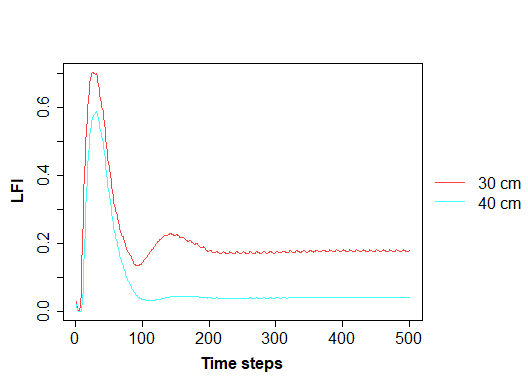

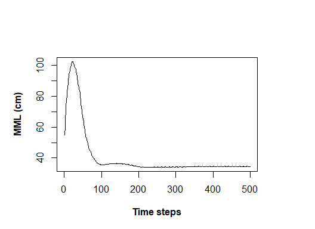

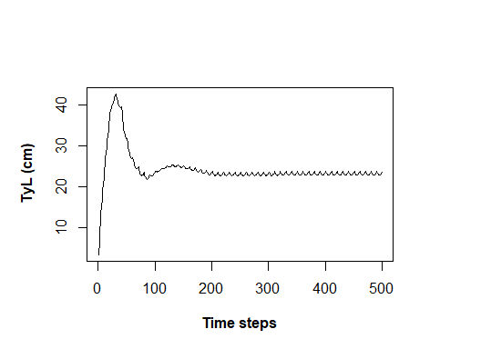

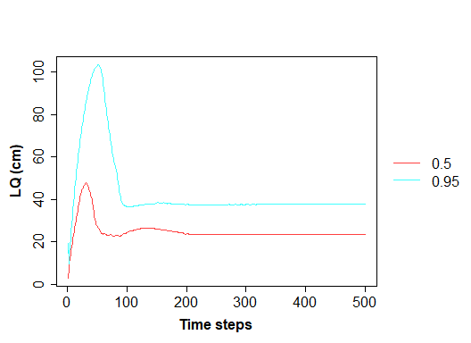

`LeMaRns` also includes the `get_indicators` and `plot_indicators` functions, which can be used to calculate and plot all four indicators using a single function call. For example, the indicators can be calculated by running:

```r
indicators <- get_indicators(inputs=NS_params, outputs=model_run, time_steps=1:500,
                             species=1:21,length_LFI=c(30, 40), prob=c(0.5, 0.95))
```

which returns a list object with the names `LFI`, `MML`, `TYL` and `LQ`.

To plot the indicators, users can again provide either `LeMans_param` and `LeMans_output` objects:

```r
plot_indicators(inputs=NS_params, outputs=model_run, time_steps=1:500, species=1:21,
                length_LFI=c(30, 40), prob=c(0.5, 0.95))
```

or they can provide the output of `get_indicators` to the plot function directly:

```r
plot_indicators(LFI=indicators[['LFI']], MML=indicators[['MML']],
                TyL=indicators[['TyL']], LQ=indicators[['LQ']],
                time_steps=1:500, species=1:21,
                length_LFI=c(30, 40), prob=c(0.5, 0.95))
```

In both cases, the following plot will be returned:

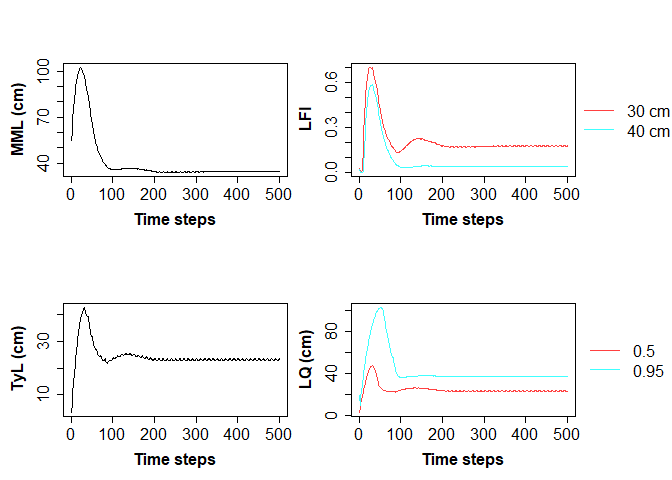

## Catch

Finally, `LeMaRns` includes in-built functions that can be used to explore catch. Catch Per Unit Effort (`CPUE`) and Catch Per Gear (`CPG`) can be calculated using the `get_CPUE()` and `get_CPG()` functions in the same way as described previously:

```r
CPUE <- get_CPUE(inputs=NS_params, outputs=model_run, time_steps=1:500, species=1:21)
CPG <- get_CPG(inputs=NS_params, outputs=model_run, time_steps=1:500, species=1:21)
```

# Case Study

In this section we give two examples of mixed fisheries and an example of finding long-term fishing targets. In the first we examine the effect on the fish species of various fishing efforts on different fleets and in the second demonstrate an example with dynamic fishing mortality. The final example calculates a Nash equilibrium.

Please note that the parameters in the example dataset in `LeMaRns` have not been calibrated to observations. Therefore the case studies are demonstrations of the package and the results should not be interpreted. For methods on calibrating these kinds of models see Thorpe et al. (2015) or Spence, Blackwell, and Blanchard (2016).

## Fishing fleets

In this case study we explore the mixed fishery example described in Thorpe et al. (2016), which involves four different fishing fleets. Here, we use idealised fleets, i.e. a single fish is caught by only one gear type. The data frame `NS_mixed_fish` contains the information on which fleet catches which species:

```r
NS_mixed_fish
```

```
#>     catch_species    curve  gear_name max_catchability
#> 1           Sprat logistic Industrial            1.060
#> 2           Npout logistic Industrial            0.477
#> 3         Sandeel logistic Industrial            0.573
#> 4        Poor cod logistic      Otter            0.548
#> 5  Long rough dab logistic       Beam            0.548
#> 6             Dab logistic       Beam            0.548
#> 7         Herring logistic    Pelagic            0.247
#> 8  Horse mackerel logistic    Pelagic            0.627
#> 9      Lemon sole logistic       Beam            0.548
#> 10           Sole logistic       Beam            0.534
#> 11       Mackerel logistic    Pelagic            0.627
#> 12        Whiting logistic      Otter            0.365
#> 13          Witch logistic       Beam            0.548
#> 14        Gurnard logistic      Otter            0.548
#> 15         Plaice logistic       Beam            0.548
#> 16     Starry ray logistic       Beam            0.548
#> 17        Haddock logistic      Otter            0.577
#> 18     Cuckoo ray logistic       Beam            0.548
#> 19       Monkfish logistic      Otter            0.548
#> 20            Cod logistic      Otter            0.882
#> 21         Saithe logistic      Otter            0.377
```

In this example, the selectivity of each species follows the `logistic` curve and requires the parameters `NS_eta` and `NS_L50`, which are provided as part of `LeMaRns`.

We first set up the `LeMans_params` object:

```r
NS_params <- LeMansParam(df=NS_par, gdf = NS_mixed_fish, tau=NS_tau, eta=NS_eta, L50=NS_L50, other=NS_other)
```

Initially we will examine the virgin biomass by running the model to equilibrium with no fishing. To do this, we set up effort and then run the model for 50 years:

```r
effort_mat <- matrix(0, 50, dim(NS_params@Qs)[3])
colnames(effort_mat) <- c("Industrial", "Otter", "Beam", "Pelagic")
model_run <- run_LeMans(NS_params, years=50, effort=effort_mat)
```

We plot Spawning Stock Biomass (SSB) to ensure it has reached equilibrium:

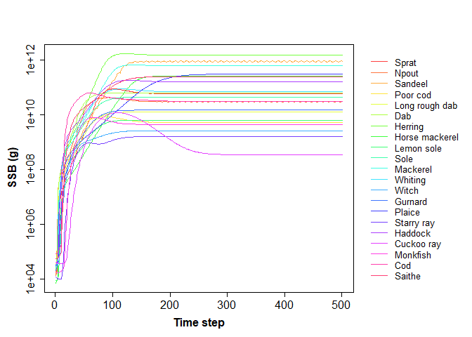

```r
plot_SSB(inputs=NS_params, outputs=model_run, full_plot_only=TRUE)
```

and then check the indicators:

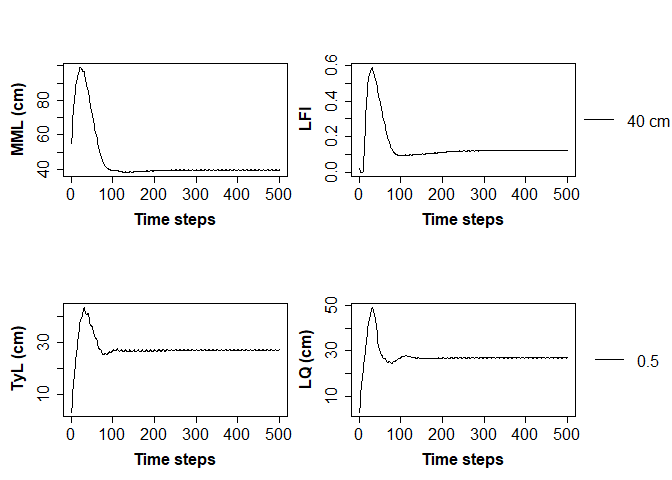

```r
plot_indicators(inputs=NS_params, outputs=model_run)
```

We take the mean of the final year of the simulation to calculate the virgin SSB:

```r
v_SSB <- colMeans(get_SSB(inputs=NS_params, outputs=model_run, time_steps=492:501))/1e6
```

In Thorpe et al. (2016) a factorial design was used to explore the effects of changing the fishing effort of different fleets. In this example we allow each of the four fleets to fish at one of five effort levels and set up a factorial design:

```r
ef_lvl <- c(0, 0.5, 1, 1.5, 2)
efs <- expand.grid(Industrial=ef_lvl, Otter=ef_lvl, Beam=ef_lvl, Pelagic=ef_lvl)
```

We run the LeMans model for 50 years from the final state of the model in the `model_run` above. For efficiency we create a function that takes in the factorial design and then runs the LeMans model:

```r
run_the_model<- function(ef){
  effort_mat <- matrix(ef, 50, dim(NS_params@Qs)[3], byrow=T)
  colnames(effort_mat) <- c("Industrial", "Otter", "Beam", "Pelagic")
  model_run <- run_LeMans(params=NS_params, N0=model_run@N[,,501],
                          years=50, effort=effort_mat)
  return(model_run)
}
```

We then run the model over the factorial design (warning this may take a few minutes):

```r
sce <- apply(efs, 1, run_the_model)
```

We then calculate the Large Fish Indicator (LFI), Typical Length (TyL) and Mean Maximum Length (MML) for all of the model runs:

```r
LFI <- unlist(lapply(lapply(sce, FUN=get_LFI, time_steps=492:501, inputs=NS_params),
                     mean))
TyL <- unlist(lapply(lapply(sce, FUN=get_TyL, time_steps=492:501, inputs=NS_params),
                     mean))
MML <- unlist(lapply(lapply(sce, FUN=get_MML, time_steps=492:501, inputs=NS_params),
                     mean))
```

We can now investigate the effect of changing the effort of each of the fishing gears on the above indicators using box-plots:

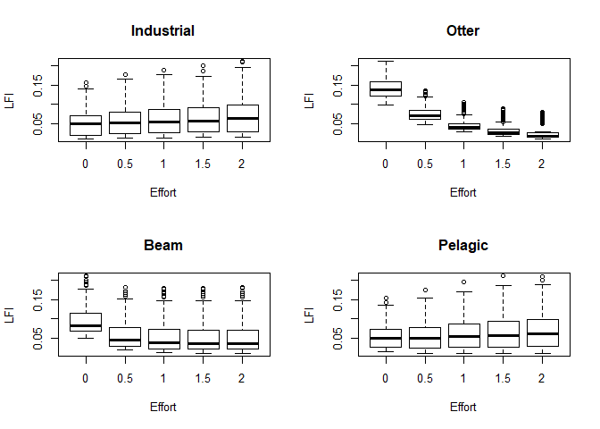

```r
par(mfrow=c(2, 2))
boxplot(LFI~efs[, 1], main="Industrial", xlab="Effort", ylab="LFI")
boxplot(LFI~efs[, 2], main="Otter", xlab="Effort", ylab="LFI")
boxplot(LFI~efs[, 3], main="Beam", xlab="Effort", ylab="LFI")
boxplot(LFI~efs[, 4], main="Pelagic", xlab="Effort", ylab="LFI")
```

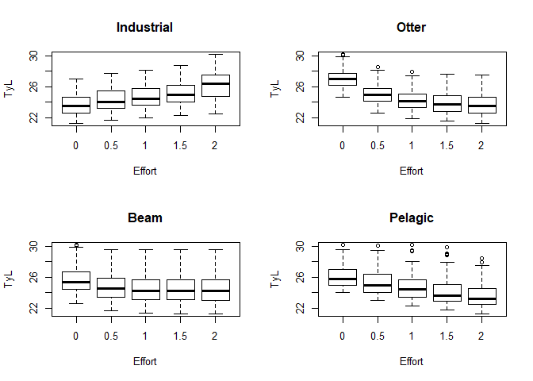

```r
par(mfrow=c(2, 2))
boxplot(TyL~efs[, 1], main="Industrial", xlab="Effort", ylab="TyL")
boxplot(TyL~efs[, 2], main="Otter", xlab="Effort", ylab="TyL")
boxplot(TyL~efs[, 3], main="Beam", xlab="Effort", ylab="TyL")
boxplot(TyL~efs[, 4], main="Pelagic", xlab="Effort", ylab="TyL")
```

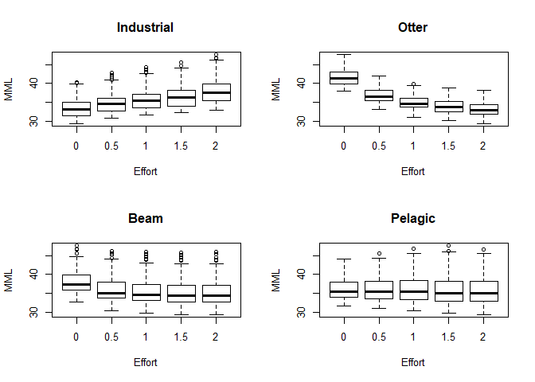

```r
par(mfrow=c(2, 2))
boxplot(MML~efs[, 1], main="Industrial", xlab="Effort", ylab="MML")
boxplot(MML~efs[, 2], main="Otter", xlab="Effort", ylab="MML")
boxplot(MML~efs[, 3], main="Beam", xlab="Effort", ylab="MML")
boxplot(MML~efs[, 4], main="Pelagic", xlab="Effort", ylab="MML")
```

All three indicators appear to be mostly driven by the otter gear, which targets larger fish species such as cod and saithe. This suggests that the three indicators are predominantly metrics of the health of the larger species rather than the smaller species.

We also investigate the state of the stocks relative to the virgin SSB:

```r
# SSB of the final years (tonnes)
new_SSB <- do.call(rbind, lapply(lapply(sce, FUN=get_SSB, time_steps=492:501,
                                        inputs=NS_params), colMeans))/1e6
# Relative SSB
rel_SSB <- t(t(new_SSB)/v_SSB)
colnames(rel_SSB) <- NS_params@species_names
```

Changes in the relative SSB of saithe based on fishing effort is shown below:

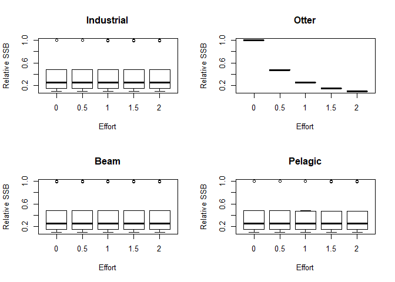

```r
par(mfrow=c(2,2))
boxplot(rel_SSB[, "Saithe"]~efs[, 1], main="Industrial", xlab="Effort",
        ylab="Relative SSB")
boxplot(rel_SSB[, "Saithe"]~efs[, 2], main="Otter", xlab="Effort",
        ylab="Relative SSB")
boxplot(rel_SSB[, "Saithe"]~efs[, 3], main="Beam", xlab="Effort",
        ylab="Relative SSB")
boxplot(rel_SSB[, "Saithe"]~efs[, 4], main="Pelagic", xlab="Effort",
        ylab="Relative SSB")
```

As expected, the SSB of saithe is most sensitive to the otter gear, which is the fleet that catches it. We now examine the effects of changes in fishing effort on horse mackerel:

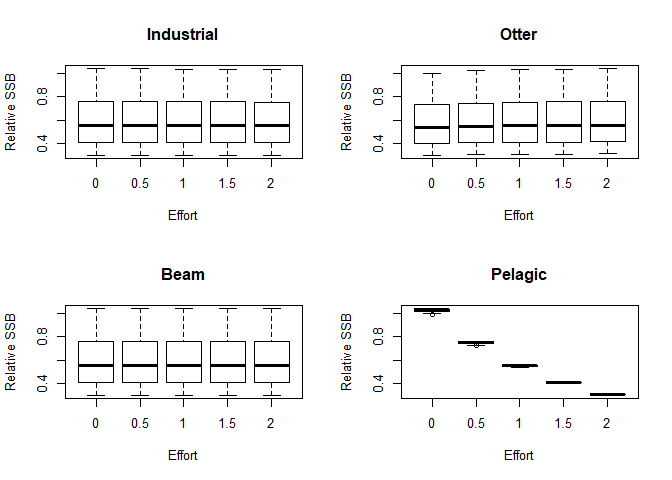

```r
par(mfrow=c(2,2))
boxplot(rel_SSB[, "Horse mackerel"]~efs[, 1], main="Industrial", xlab="Effort",
        ylab="Relative SSB")
boxplot(rel_SSB[, "Horse mackerel"]~efs[, 2], main="Otter", xlab="Effort",
        ylab="Relative SSB")
boxplot(rel_SSB[, "Horse mackerel"]~efs[, 3], main="Beam", xlab="Effort",
        ylab="Relative SSB")
boxplot(rel_SSB[, "Horse mackerel"]~efs[, 4], main="Pelagic", xlab="Effort",
        ylab="Relative SSB")
```

In Thorpe et al. (2016), a stock is said to be at risk of collapse if the SSB falls below 10% of the virgin SSB. Below we show the number of stocks that are at risk of collapse for each of the fishing scenarios:

```r
risk <- apply(rel_SSB, 1, function(x){return(sum(x<0.1))})

par(mfrow=c(2, 2))
boxplot(risk~efs[, 1], main="Industrial", xlab="Effort", ylab="Stocks at risk")
boxplot(risk~efs[, 2], main="Otter", xlab="Effort", ylab="Stocks at risk")
boxplot(risk~efs[, 3], main="Beam", xlab="Effort", ylab="Stocks at risk")
boxplot(risk~efs[, 4], main="Pelagic", xlab="Effort", ylab="Stocks at risk")
```

[output not shown]

The number of stocks at risk of collapse is sensitive to the otter fleet and the beam fleet. Below we plot the mean number of stocks at risk by varying the effort of the otter and the beam fleets:

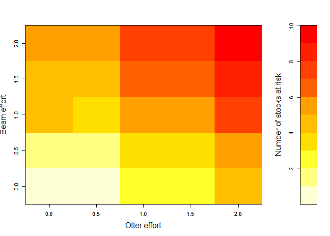

```r
z_mat <- outer(ef_lvl, ef_lvl, FUN=function(x, y, efs) {
  mapply(function(x, y, efs) {
  mean(risk[intersect(which(efs[, 2]==x), which(efs[, 3]==y))])}, x=x, y=y,
  MoreArgs=list(efs=efs))
}, efs=efs)
layout(matrix(c(1,1,1,1,1,2), nrow=1, byrow=TRUE))
image(z=-z_mat, x=ef_lvl, y=ef_lvl, axes=T, cex.lab=1.5, xlab="Otter effort", ylab="Beam effort")
axis(1); axis(2); box()
image(z=-matrix(sort(unique(as.numeric(z_mat))), nrow=1),
      y=sort(unique(as.numeric(z_mat))), axes=F, cex.lab=1.5,
      ylab="Number of stocks at risk")
axis(2); box()
box()
```

## Dynamic fishing

We now investigate a dynamical fishing scenario. We first set up effort for the four gears with varying fishing effort, shown below:

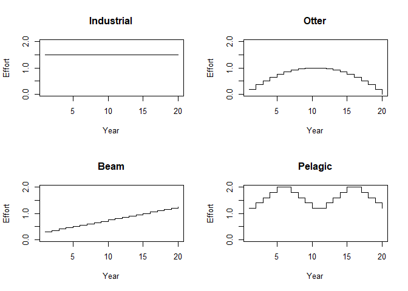

```r
Industrial <- rep(1.5, 20)
Otter <- -1/100*1:20*(1:20-20)
Beam <- 1:20*1/20+0.25
Pelagic <- 1+c(1:5*1/5, 5:1*1/5, 1:5*1/5, 5:1*1/5)
par(mfrow=c(2, 2))
plot(1:20, Industrial, ylab="Effort", main="Industrial", xlab="Year",
     ylim=c(0, 2), type="s")
plot(1:20, Otter, ylab="Effort", main="Otter", xlab="Year",
     ylim=c(0, 2), type="s")
plot(1:20, Beam, ylab="Effort", main="Beam", xlab="Year",
     ylim=c(0, 2), type="s")
plot(1:20, Pelagic, ylab="Effort", main="Pelagic", xlab="Year",
     ylim=c(0, 2), type="s")
```

We then run the model for 20 years from the unfished state (`model_run`) and calculate the annual catches for those 20 years:

```r
# Set up effort for the model run
effort_mat <- cbind(Industrial, Otter, Beam, Pelagic)
colnames(effort_mat) <- c("Industrial", "Otter", "Beam", "Pelagic")
model_run_dyn <- run_LeMans(params=NS_params, N0=model_run@N[,,501],
                            years=20, effort=effort_mat)
catches <- get_annual_catch(inputs=NS_params, outputs=model_run_dyn)/1e6 # in tonnes
colnames(catches) <- NS_params@species_names
```

We can then plot the annual catches for different species:

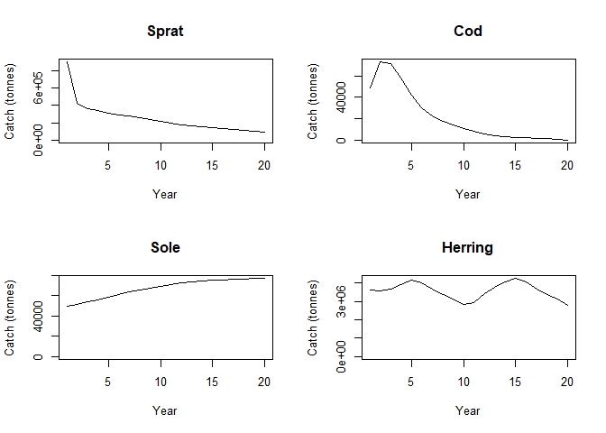

```r
par(mfrow=c(2, 2))
plot(1:20, catches[, "Sprat"], type="l", main="Sprat", xlab="Year",
     ylab="Catch (tonnes)", ylim=c(0, max(catches[, "Sprat"])))
plot(1:20, catches[, "Cod"], type="l", main="Cod", xlab="Year",
     ylab="Catch (tonnes)", ylim=c(0, max(catches[, "Cod"])))
plot(1:20, catches[, "Sole"], type="l", main="Sole", xlab="Year",
     ylab="Catch (tonnes)", ylim=c(0,max(catches[, "Sole"])))
plot(1:20, catches[, "Herring"], type="l", main="Herring", xlab="Year",
     ylab="Catch (tonnes)", ylim=c(0, max(catches[, "Herring"])))
```

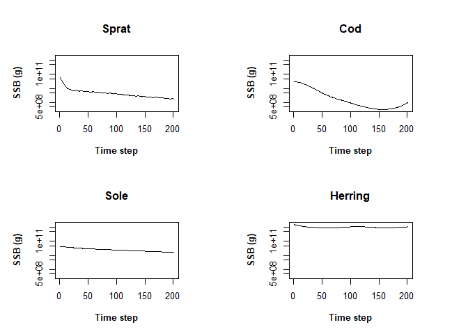

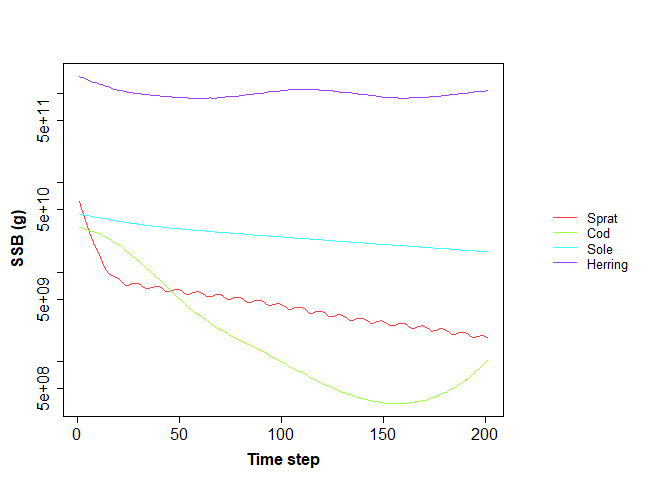

```r
plot_SSB(inputs=NS_params, outputs=model_run_dyn,
         species=c("Sprat", "Cod", "Sole", "Herring"),
         full_plot_only=FALSE)
```

We also calculate the total catch for each gear and plot it for each year:

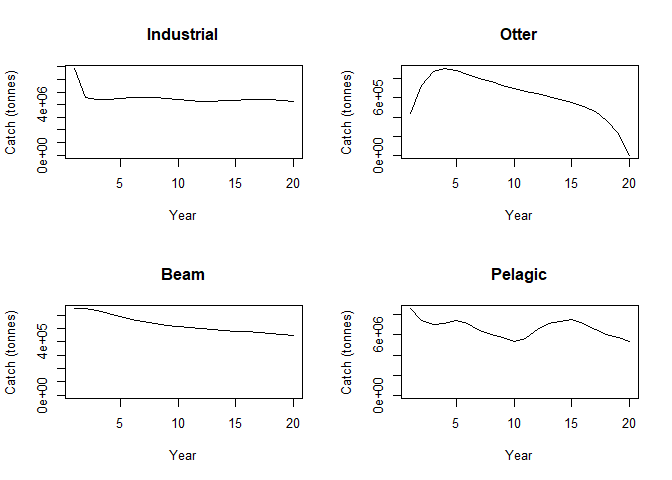

```r
catch_per_gear <- get_CPG(inputs=NS_params, outputs=model_run_dyn, effort=effort_mat)
tot_pg <- apply(catch_per_gear, c(2, 3), sum)/1e6
year <- rep(1:20, each=10)
# Total catch per gear per year
tot_pgpy <- t(sapply(1:20, function(x, year){
  tele <- which(year==x)
  if (length(tele)>1){
    return(rowSums(tot_pg[, tele]))
  }
  return(tot_pg[, tele])
}, year=year))

par(mfrow=c(2, 2))
plot(1:20, tot_pgpy[, 1], type="l", ylim=c(0, max(tot_pgpy[, 1])), xlab="Year",
     main="Industrial", ylab="Catch (tonnes)")
plot(1:20, tot_pgpy[, 2], type="l", ylim=c(0, max(tot_pgpy[, 2])), xlab="Year",
     main="Otter", ylab="Catch (tonnes)")
plot(1:20, tot_pgpy[, 3], type="l", ylim=c(0, max(tot_pgpy[, 3])), xlab="Year",
     main="Beam", ylab="Catch (tonnes)")
plot(1:20, tot_pgpy[, 4], type="l", ylim=c(0, max(tot_pgpy[, 4])), xlab="Year",
     main="Pelagic", ylab="Catch (tonnes)")
```

We can also investigate the Catch Per Unit Effort (CPUE) for each species. We calculate the mean CPUE across each year:

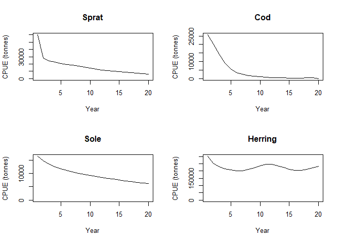

```r
CPUE <- get_CPUE(inputs=NS_params, outputs=model_run_dyn, effort=effort_mat)/1e6
cpue_py <- t(sapply(1:20, function(x, year){
  tele <- which(year==x)
  if (length(tele)>1){
    return(colMeans(CPUE[tele, ]))
  }
  return(CPUE[tele, ])
}, year=year))

colnames(cpue_py) <- NS_params@species_names

par(mfrow=c(2, 2))
plot(1:20, cpue_py[, "Sprat"], type="l", main="Sprat", xlab="Year",
     ylab="CPUE (tonnes)", ylim=c(0, max(cpue_py[, "Sprat"])))
plot(1:20, cpue_py[, "Cod"], type="l", main="Cod", xlab="Year",
     ylab="CPUE (tonnes)", ylim=c(0, max(cpue_py[, "Cod"])))
plot(1:20, cpue_py[, "Sole"], type="l", main="Sole", xlab="Year",
     ylab="CPUE (tonnes)", ylim=c(0, max(cpue_py[, "Sole"])))
plot(1:20, cpue_py[, "Herring"], type="l", main="Herring", xlab="Year",
     ylab="CPUE (tonnes)", ylim=c(0, max(cpue_py[, "Herring"])))
```

Sprat, Cod and sole are always overfished and herring is overfished in some years and underfished in others.

In `LeMaRns` it is possible for a species to be caught by multiple gears. To demonstrate this we add another fleet - a `Recreational` fleet. The selectivity for this fleet is `knife-edge` and it catches cod, haddock, herring, horse mackerel, mackerel, plaice, saithe and whiting, with all fish exceeding the minimum landing size `Lmin` being retained:

```r
rec_fish <- data.frame(catch_species=c("Cod", "Haddock", "Herring", "Horse mackerel",
                                       "Mackerel", "Plaice", "Saithe", "Whiting"),
                       curve=rep("knife-edge"), gear_name="Recreational")
rec_fish$max_catchability <- c(0.01, 0.01, 0.005, 0.05, 0.05, 0.01, 0.01, 0.02)
Lmin <- c(35, 30, 20, 15, 30, 27, 35, 27)
```

To run the `LeMansParam` function `rec_fish` and `NS_mixed_fish` need to be combined:

```r
gdf <- rbind(NS_mixed_fish, rec_fish)
```

and `L50`, `eta` and `Lmin` must be the same size as `nrow(gdf)`:

```r
eta1 <- c(NS_eta, rep(0, 8))
L501 <- c(NS_L50, rep(0, 8))
Lmin1 <- c(rep(0, 21), Lmin)
```

We can then create the `LeMans_param` object and effort:

```r
NS_params_rec <- LeMansParam(df=NS_par, gdf = gdf, tau=NS_tau, eta=eta1, L50=L501,
                             other=NS_other, Lmin=Lmin1)
effort_mat1 <- cbind(effort_mat, 0.1+1:20*0.05/20)
colnames(effort_mat1)[5] <- "Recreational"
```

with the effort of the recreational fishing fleet being:

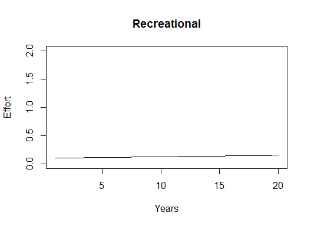

```r
plot(1:20, effort_mat1[, "Recreational"], xlab="Years", ylab="Effort", type="l",
     ylim=c(0, 2), main="Recreational")
```

We then run the model:

```r
model_run_rec <- run_LeMans(params=NS_params_rec, N0=model_run@N[,,501],
                            years=20, effort=effort_mat1)
```

and explore the catches for the recreational fleet:

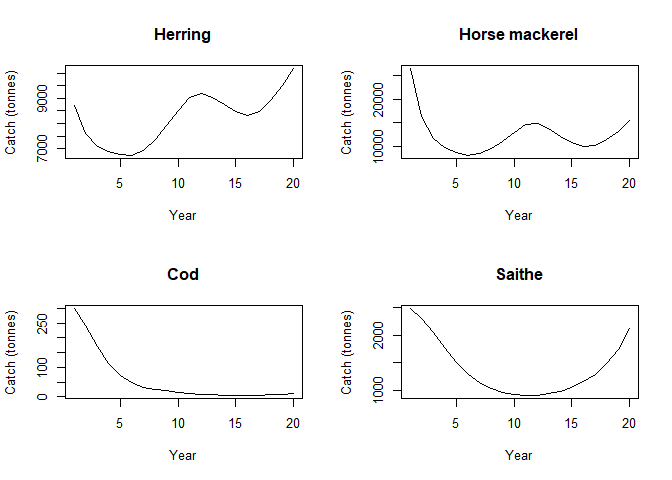

```r
catch_per_gear_rec <- get_CPG(inputs=NS_params_rec, outputs=model_run_rec, effort=effort_mat1)
rec_py <- t(sapply(1:20, function(x, year){
  tele <- which(year==x)
  if (length(tele)>1){
    return(rowSums(catch_per_gear_rec[, 5, tele]))
  }
  return(catch_per_gear_rec[, 5, tele])
}, year=year))/1e6
colnames(rec_py) <- NS_params_rec@species_names

par(mfrow=c(2, 2))
plot(1:20, rec_py[, "Herring"], type="l", main="Herring", xlab="Year",
     ylab="Catch (tonnes)")
plot(1:20, rec_py[, "Mackerel"], type="l", main="Horse mackerel", xlab="Year",
     ylab="Catch (tonnes)")
plot(1:20, rec_py[, "Cod"], type="l", main="Cod", xlab="Year",
     ylab="Catch (tonnes)")
plot(1:20 ,rec_py[, "Saithe"], type="l", main="Saithe", xlab="Year",
     ylab="Catch (tonnes)")
```

## Nash equilibrium

Fish stocks are often managed by considering the fishing mortality that maximises the long-term yield, i.e. the Maximum Sustainable Yield (MSY). We can define $f_i(F_i, F_{-i})$ as the long-term catch of the $i$th stock, where $F_i$ is the fishing mortality of the $i$th stock and $F_{-i}$ is the fishing mortalities of the other stocks. Many stocks are managed on a stock by stock basis using single-species models. This means that
$$\begin{equation*}
f_i(F_i,F_{-i})=f_i(F_i,F'_{-i}),
\end{equation*}$$
$\forall{}F'_{-i}$ and we can define
$$\begin{equation*}
F_{MSY,i}={\text{arg}\max}_{F_i}f_i(F_i,F'_{-i}).
\end{equation*}$$
In the single-species world this is commonly well defined. However, in the multispecies world stocks interact with one another and the fishing mortality of the $j$th stock affects the catch of the $i$th stock, i.e.
$$\begin{equation*}
f_i(F_i,F_{-i})\neq{}f_i(F_i).
\end{equation*}$$
We therefore need to define a multispecies maximum sustainable yield. One possibility is the Nash equilibrium Thorpe et al. (2016), which is defined as the point at which we are unable to increase $f_i(F_i,F_{-i})$ by changing $F_i$ only, for all $i$. Formally, $F_{Nash,i},\forall{}i$ is a Nash equilibrium when
$$\begin{equation*}
\forall{}i,F_i:f_i(F_{Nash,i},F_{Nash,-i})\geq{}f_i(F_{i},F_{Nash,-i}).
\end{equation*}$$

We use the `LeMaRns` package to calculate the Nash equilibrium. First we initialise a model run:

```r
NS_params_n <- LeMansParam(NS_par, tau=NS_tau, eta=NS_eta, L50=NS_L50, other=NS_other)
model_run_n_init <- run_LeMans(NS_params_n, years=50)
# Set the initial state
N0 <- model_run_n_init@N[,,501]
```

We then create a function that returns the negative mean catch of the `i`th species in the 20th year with fishing effort `x` for the `i`th species and `eff` for the rest. As we have set `apply(NS_params_n@Qs,3,max)` to be 1 using `max_catchability`, the maximum fishing mortality of each species is `eff`.

```r
calc_catch<-function(x,i,eff){
  eff[i] <- x
  tmp <- run_LeMans(NS_params_n, N0=N0, years=20, effort=matrix(eff, nrow=20, ncol=21, byrow=T))
  return(mean(tail(colSums(tmp@Catch[,i,]), 10)))
}
```

Starting from $F_{MSY}$ in Thorpe et al. (2016), we iteratively optimise the fishing effort for each species. We continue this process until the difference in the optimal effort and the effort at the start of the optimisation differ by less than `0.01` for all species.

```r
eff <- fmsy <-c(1.3, 0.35, 0.35, 0.72, 0.6, 0.41, 0.25, 0.5, 0.33, 0.22, 0.32, 0.21, 0.27,
                0.27, 0.25, 0.15, 0.30, 0.11, 0.1, 0.19, 0.3)
stat <- rep(FALSE, 21)
while(any(stat==FALSE)){
  for (i in 1:21){
    opts <- optim(eff[i], calc_catch, i=i, eff=eff, method="Brent", lower=0, upper=2,control = list(fnscale = -1))
    stat[i] <- abs(eff[i]-opts$par)<0.01
    eff[i] <- opts$par
  }
}
```

`eff` is the Nash equilibrium. Below we plot the SSB for the Nash equilibrium:

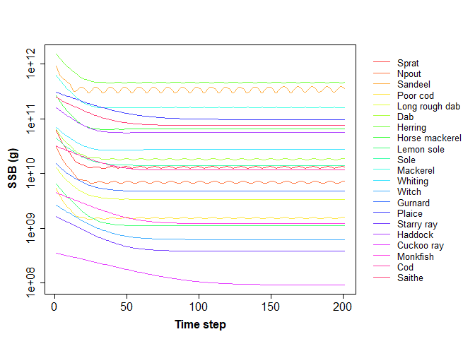

```r
nash <- run_LeMans(NS_params_n, N0=N0, years=20, effort=matrix(eff, nrow=20, ncol=21, byrow=T))
plot_SSB(inputs=NS_params_n, outputs=nash)
```

To compare this to the single-species MSY we have to change the rules slightly as we have to specify the fishing mortality rates for the other species. Arbitrarily we choose to set `effort=fmsy` for all the but the $i$th species when calculating $F_{MSY,i}$. This is:

```r
fmsy_lm <- sapply(1:21, function(i, eff){optim(eff[i], calc_catch, i=i, eff=eff,
                                           method="Brent", lower=0, upper=2,control = list(fnscale = -1))$par},
                eff=fmsy)
msy <- run_LeMans(NS_params_n, N0=N0, years=20, effort=matrix(fmsy_lm, nrow=20, ncol=21, byrow=T))
```

We then compare $F_{MSY}$ and $F_{Nash}$ in this study:

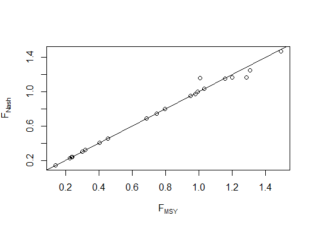

```r
plot(fmsy_lm, eff, ylab=expression(F[Nash]), xlab=expression(F[MSY]))
abline(a=0, b=1)
```

The two appear to be similar for most species, particularly those with lower values of $F_{MSY}$ and $F_{Nash}$, however they appear to differ more for larger values.

We comment on the arbitrariness of the choice of fishing mortality by pointing out that had we set the other species fishing mortality values to be $F_{Nash,-i}$ when calculating $F_{MSY,i}$, then $F_{MSY,i}=F_{Nash,i}$ by definition.

# References

Conner, L., R. Matson, and F.L. Kelly. 2017. “Length-Weight Relationships for Common Freshwater Fish Species in Irish Lakes and Rivers.” *Biology and Environment, Proceedings of the Royal Irish Academy* 117B (2): 65–75.

Fulton, E.A., J. Link, I.C. Kaplan, P. Johnson, P. Savina-Rolland, C. Ainsworth, P. Horne, et al. 2011. “Lessons in Modelling and Management of Marine Ecosystems the Atlantis Experience.” *Fish and Fisheries* 12: 171–88.

Hall, S.J., J.S. Collie, D.E. Duplisea, S. Jennings, M. Bravington, and J. Link. 2006. “A Length-Based Multispecies Model for Evaluating Community Responses to Fishing.” *Canadian Journal of Fisheries and Aquatic Sciences* 63 (6): 1344–59.

Ogle, D.H. 2016. *Introductory Fisheries Analyses with R*. CRC Press.

Polovina, J.J. 1984. “Model of a Coral Reef Ecosystem. I, the ECOPATH Model and Its Application to French Frigate Shoals.” *Coral Reefs* 3 (1): 1–11.

Scott, F., J. L. Blanchard, and K.H. Andersen. 2014. “Mizer an R Package for Multispecies, Trait-Based and Community Size Spectrum Ecological Modelling.” *Methods in Ecology and Evolution* 5: 1121–5.

Speirs, D., E. Guirey, W. Gurney, and M. Heath. 2010. “A Length-Structured Partial Ecosystem Model for Cod in the North Sea.” *Fisheries Research* 106 (3): 474–94.

Spence, M.A., P.G. Blackwell, and J.L. Blanchard. 2016. “Parameter Uncertainty of a Dynamic Multi-Species Size Spectrum Model.” *Canadian Journal of Fisheries and Aquatic Sciences* 73 (4): 589–97.

Thorpe, R.B., P.J. Dolder, S. Reeves, P. Robinson, and S. Jennings. 2016. “Assessing Fishery and Ecological Consequences of Alternate Management Options for Multispecies Fisheries.” *ICES Journal of Marine Science* 73 (6): 1503–12.

Thorpe, R.B., W.J.F. LeQuesne, F. Luxford, J.S. Collie, and S. Jennings. 2015. “Evaluation and Management Implications of Uncertainty in a Multispecies Size-Structured Model of Population and Community Responses to Fishing.” *Methods in Ecology and Evolution* 6: 49–58.